# DAR F21 Project Status Notebook:

DeFi

Roman Vakhrushev (vakhrr)

10/03/2021

## Biweekly Work Summary

- RCS ID: vakhrr
- Project Name: Blockchain DeFi
- These two weeks I was working on analyzing coins for liquidation
- First week I started by analyzing the relationship between principal and collateral in liquidation transactions
- Second week I had to fix several errors in the initial analysis and then I made some small analysis on the transactions related to liquidation over time
- Branch: dar-vakhrr

## Personal Contribution

All contributions were completed by me.

## Discussion of Primary Findings

### What did you want to know?

I wanted to study how the distribution of coins for liquidation looks like, understand what coins are used more as collateral and principal and what coins are not used at all. I also wanted to see how liquidation transactions are distributed over time and verify if there are any interesting trends there.

### How did you go about finding it?

I decided to analyze the data using pairs of coins (collateral, principal). I had to create new data frames out of the initial data frame, extended them with new columns, and built graphs and tables out of it. For analysis of transactions over time I also created new data frames and build visualizations.

### What did you find?

```r
#data collection as always
df<-read_rds('../../Data/transactions.Rds')
# Use deplyr to drop NA reserves, add the counts and then kep only the top 20
reservecoins <- df %>%  drop_na(reserve) %>%
count(reserve) %>%
arrange(-n) %>%
head(20)
```

```r
#Create cointype function to label all coins by types correctly,
#This is useful for visualizations

coinType <- function(coin) {
    #stable_coins <- list("USDC","USDT","DAI","BUSD","SUSD","GUSD","TUSD")
    if(str_contains(coin,"USD",ignore.case = TRUE))
    {
      result = "stable"
    }
    else if(str_contains(coin,"DAI",ignore.case = TRUE))
    {
      result = "stable"
    }
    else
    {
      result = "non-stable"
    }
    return(result)
}

#Main data frame for analysis of liquidations, includes information on total and
#average values of collateral and principal

LiquidSummary <- df%>% filter(type == "liquidation") %>% group_by(collateralReserve, principalReserve)

LiquidSummary <- df%>% filter(type == "liquidation") %>% group_by(collateralReserve, principalReserve) %>% summarize(avg_usd_princ = mean(amountUSDPincipal),total_usd_princ = sum(amountUSDPincipal), avg_usd_collat=mean(amountUSDCollateral),total_usd_collat=sum(amountUSDCollateral),avg_eth_princ = mean(reservePriceETHPrincipal*principalAmount),total_eth_princ = sum(reservePriceETHPrincipal*principalAmount), avg_eth_collat=mean(reservePriceETHCollateral*collateralAmount),total_eth_collat=sum(reservePriceETHCollateral*collateralAmount),collateralType = coinType(collateralReserve), principalType = coinType(principalReserve),n=n())
#These are just ordered versions of LiquidSummary too see what coins are used
#more for liquidations
LiquidSummary <- LiquidSummary[order(-LiquidSummary$total_usd_princ),]
print(head(LiquidSummary,5))
```

```
## # A tibble: 5 × 13
## # Groups:   collateralReserve [3]
##   collateralReserve principalReserve avg_usd_princ total_usd_princ avg_usd_collat
##   <fct>             <fct>                    <dbl>           <dbl>          <dbl>
## 1 WETH              USDC                   104443.       89925227.       1.10e-13
## 2 WETH              USDT                    87256.       64045874.       9.16e-14
## 3 WBTC              USDC                   206599.       51029921.       2.27e+ 5
## 4 WETH              DAI                     68264.       46009992.       7.17e-14
## 5 LINK              USDC                    44420.       24608887.       4.89e+ 4
## # … with 8 more variables: total_usd_collat <dbl>, avg_eth_princ <dbl>,
## #   total_eth_princ <dbl>, avg_eth_collat <dbl>, total_eth_collat <dbl>,
## #   collateralType <chr>, principalType <chr>, n <int>
```

```r
LiquidSummary <- LiquidSummary[order(-LiquidSummary$total_usd_collat),]
print(head(LiquidSummary,5))
```

```
## # A tibble: 5 × 13
## # Groups:   collateralReserve [3]
##   collateralReserve principalReserve avg_usd_princ total_usd_princ avg_usd_collat
##   <fct>             <fct>                    <dbl>           <dbl>          <dbl>
## 1 WBTC              USDC                   206599.       51029921.        227173.
## 2 LINK              USDC                    44420.       24608887.         48893.
## 3 WBTC              USDT                   172065.       23056656.        189227.
## 4 LINK              USDT                    41244.       12455699.         45359.
## 5 USDC              USDT                   416198.       10404949.        437447.
## # … with 8 more variables: total_usd_collat <dbl>, avg_eth_princ <dbl>,
## #   total_eth_princ <dbl>, avg_eth_collat <dbl>, total_eth_collat <dbl>,
## #   collateralType <chr>, principalType <chr>, n <int>
```

These tables provide the initial analysis for liquidation coins. The first table shows the first five entries of the data frame ordered by total principal (in USD), while the second table shows the same but for total collateral (in USD). From these, we can initially draw some basic conclusion. First, almost all combinations of coins have non-stable coin for collateral and stable coin for principal. Second, we can observe popular coins for collateral and principal, these are WBTC, WETH for collateral and USDC, USDT for principal. Lastly, we see that different combinations of coins, even ordered, are still quite different. For example, combinations (WETH,USDT) and (WBTC,USDC) are very different in average value for principal while quite close in total value for principal.

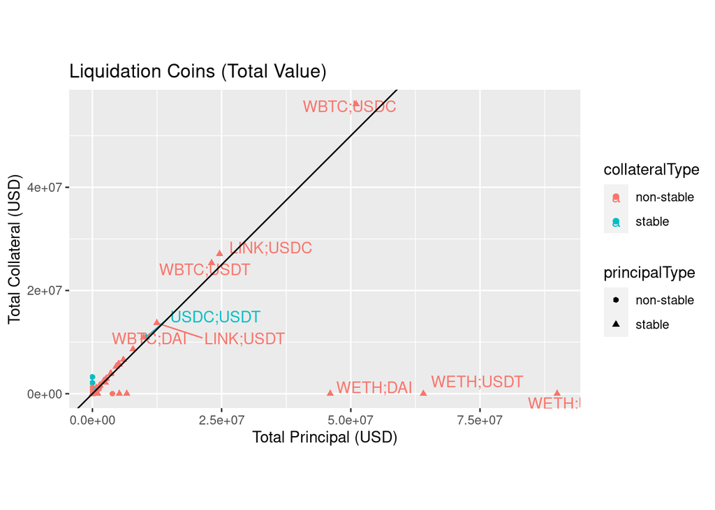

```r
#Build plots for total principal/ total collateral (USD)

p <- ggplot(LiquidSummary,aes(x = total_usd_princ, y = total_usd_collat,color = collateralType, shape = principalType)) + geom_point() + ggtitle("Liquidation Coins (Total Value)") + geom_text_repel(aes(label=ifelse(total_usd_princ>1.0e+07|total_usd_collat>1.0e+07,paste(as.character(collateralReserve), as.character(principalReserve), sep=";"),'')),hjust=0,vjust=1) + geom_abline() + xlab("Total Principal (USD)") + ylab("Total Collateral (USD)")

p <- p + coord_equal(ratio = 1)

#Build plots for total principal/ total collateral (ETH)
p_eth <- ggplot(LiquidSummary,aes(x = total_eth_princ, y = total_eth_collat,color = collateralType, shape = principalType)) + geom_point() + ggtitle("Liquidation Coins (Total Value in ETH)") + geom_text_repel(aes(label=ifelse(total_eth_princ>2.0e+07|total_eth_collat>2.0e+05,paste(as.character(collateralReserve), as.character(principalReserve), sep=";"),'')),hjust=0,vjust=1) + geom_abline() + xlab("Total Principal (ETH)") + ylab("Total Collateral (ETH)")



p_eth <- p_eth + coord_equal(ratio = 1)


LiquidNCollat <- LiquidSummary %>% group_by(collateralReserve) %>% summarize(total_liquidations = sum(n))

LiquidNCollat <- LiquidNCollat[order(-LiquidNCollat$total_liquidations),]

LiquidNPrinciple <- LiquidSummary %>% group_by(principalReserve) %>% summarize(total_liquidations = sum(n))

LiquidNPrinciple <- LiquidNPrinciple[order(-LiquidNPrinciple$total_liquidations),]

p
```

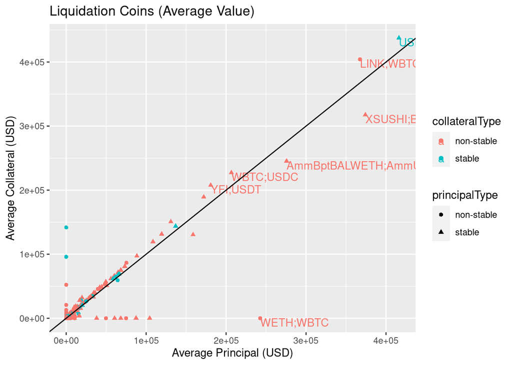

```r
#This graph is almost the same, so commented out
#p_eth

#ggplotly(p)

p_avg <- ggplot(LiquidSummary,aes(avg_usd_princ,avg_usd_collat,color = collateralType, shape = principalType)) + geom_point() + ggtitle("Liquidation Coins (Average Value)") + geom_text(aes(label=ifelse(avg_usd_princ>2.0e+05|avg_usd_collat>2.0e+05,paste(as.character(collateralReserve), as.character(principalReserve), sep=";"),'')),hjust=0,vjust=1) + geom_abline()  + xlab("Average Principal (USD)") + ylab("Average Collateral (USD)")

#ggplotly(p2)

p_avg
```

```r
dfst <- df %>% filter(type == "liquidation") %>% filter(collateralReserve != "WETH") %>% filter(principalReserve != "WETH") %>% filter(amountUSDCollateral<amountUSDPincipal)

count(dfst)
```

```
##     n
## 1 169
```

```r
head(dfst,10)
```

```
##    amount borrowRate borrowRateMode onBehalfOf         pool reserve  timestamp
## 1      NA         NA                        NA 1.034668e+48         1619145033
## 2      NA         NA                        NA 9.862324e+47         1621760653
## 3      NA         NA                        NA 1.034668e+48         1613996726
## 4      NA         NA                        NA 9.862324e+47         1626068711
## 5      NA         NA                        NA 9.862324e+47         1622094467
## 6      NA         NA                        NA 1.034668e+48         1610380545
## 7      NA         NA                        NA 1.034668e+48         1614780766
## 8      NA         NA                        NA 1.034668e+48         1621457161
## 9      NA         NA                        NA 9.862324e+47         1623101650
## 10     NA         NA                        NA 9.862324e+47         1626068229
##            user        type reservePriceETH reservePriceUSD amountUSD
## 1  3.748214e+47 liquidation              NA              NA        NA
## 2  1.159947e+48 liquidation              NA              NA        NA
## 3  4.958860e+47 liquidation              NA              NA        NA
```

[output cut: 51 more lines]

```r
#df<-df %>% filter(type == "liquidation") %>% group_by(timestamp, reserveUSDPrincipal) %>% filter(collateralReserve == "WBTC") %>% filter(principalReserve == "USDC")

#df <- df %>% mutate(timestamp = as_date(timestamp))

LiquidSummary2 <- LiquidSummary %>% mutate(collat_princ_rat = total_usd_collat/total_usd_princ)

LiquidSummary2
```

```
## # A tibble: 210 × 14
## # Groups:   collateralReserve [24]
##    collateralReserve principalReserve avg_usd_princ total_usd_princ
##    <fct>             <fct>                    <dbl>           <dbl>
##  1 WBTC              USDC                   206599.       51029921.
##  2 LINK              USDC                    44420.       24608887.
##  3 WBTC              USDT                   172065.       23056656.
##  4 LINK              USDT                    41244.       12455699.
##  5 USDC              USDT                   416198.       10404949.
##  6 WBTC              DAI                     64817.        9916969.
##  7 AAVE              USDC                    68316.        7856286.
##  8 LINK              DAI                     22021.        5989663.
##  9 YFI               USDT                   180748.        5060936.
## 10 AAVE              USDT                    60251.        5181574.
## # … with 200 more rows, and 10 more variables: avg_usd_collat <dbl>,
## #   total_usd_collat <dbl>, avg_eth_princ <dbl>, total_eth_princ <dbl>,
## #   avg_eth_collat <dbl>, total_eth_collat <dbl>, collateralType <chr>,
## #   principalType <chr>, n <int>, collat_princ_rat <dbl>
```

```r
dfl<-df %>% filter(type == "liquidation")

dfl$collateralType <- mapply(coinType, dfl$collateralReserve)

dfl$principalType <- mapply(coinType, dfl$principalReserve)


dfl<-dfl %>% mutate(timestamp = as_datetime(timestamp, tz = "UTC"))

head(dfl,20)
```

```
##    amount borrowRate borrowRateMode onBehalfOf         pool reserve
## 1      NA         NA                        NA 1.034668e+48
## 2      NA         NA                        NA 1.034668e+48
## 3      NA         NA                        NA 1.034668e+48
## 4      NA         NA                        NA 1.034668e+48
## 5      NA         NA                        NA 1.034668e+48
## 6      NA         NA                        NA 1.034668e+48
## 7      NA         NA                        NA 1.034668e+48
## 8      NA         NA                        NA 1.034668e+48
## 9      NA         NA                        NA 1.034668e+48
## 10     NA         NA                        NA 1.034668e+48
## 11     NA         NA                        NA 1.034668e+48
## 12     NA         NA                        NA 1.034668e+48
## 13     NA         NA                        NA 1.034668e+48
## 14     NA         NA                        NA 9.862324e+47
```

[output cut: 132 more lines]

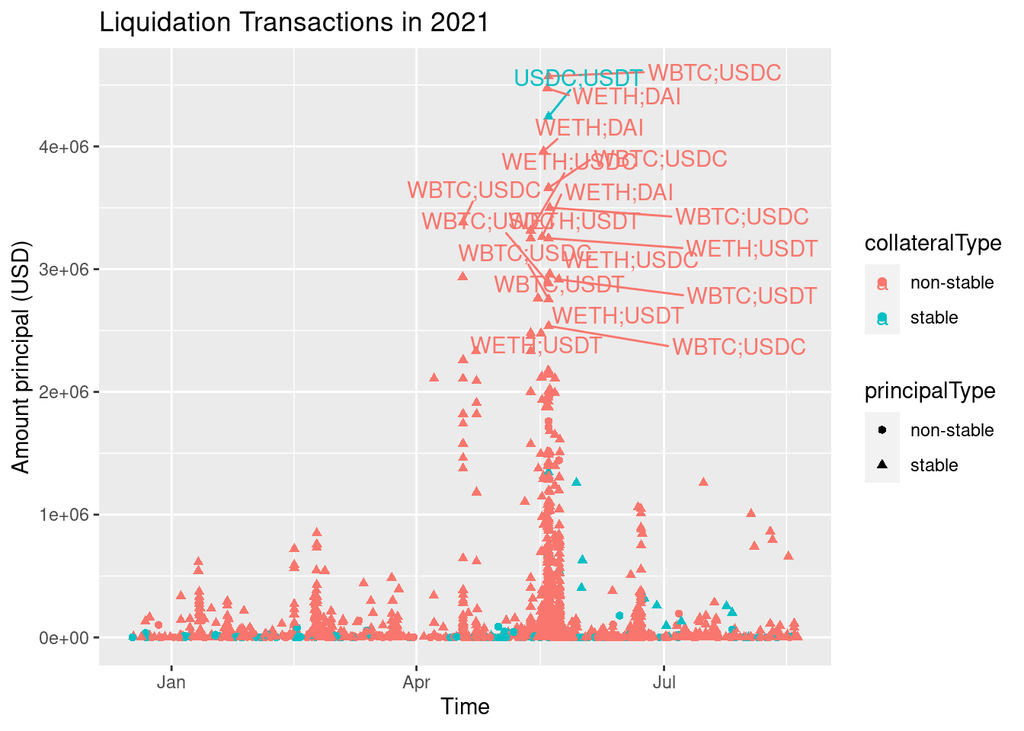

```r
p <- ggplot(dfl,aes(x = timestamp, y = amountUSDPincipal,color = collateralType, shape = principalType)) + geom_point() + ggtitle("Liquidation Transactions in 2021") +  geom_text_repel(aes(label=ifelse(amountUSDPincipal>2.0e+06,paste(as.character(collateralReserve), as.character(principalReserve), sep=";"),'')),hjust=0,vjust=1) + xlab("Time") + ylab("Amount principal (USD)")

p
```

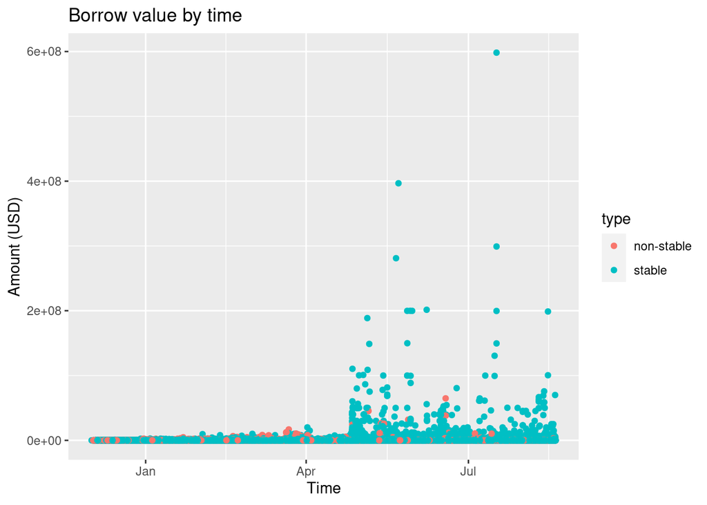

```r
BorrowSummary <- df %>% filter(type == "borrow")

BorrowSummary$type <- mapply(coinType,BorrowSummary$reserve)

p2 <- ggplot(BorrowSummary,aes(x = as_datetime(timestamp, tz = "UTC"), y = amountUSD, color = type)) + geom_point() + ggtitle("Borrow value by time") + xlab("Time") + ylab("Amount (USD)")

p2
```

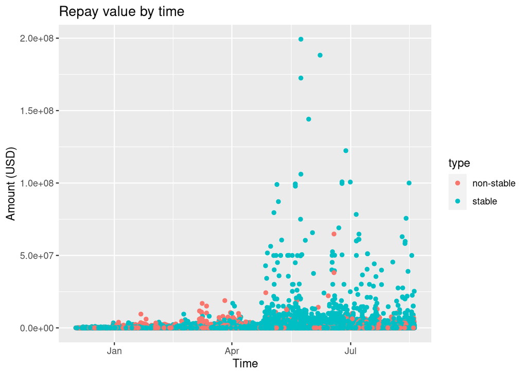

```r
RepaySummary <- df %>% filter(type == "repay")

RepaySummary$type <- mapply(coinType,RepaySummary$reserve)

p3 <- ggplot(RepaySummary,aes(as_datetime(timestamp, tz = "UTC"), y = amountUSD, color = type)) + geom_point() + ggtitle("Repay value by time") + xlab("Time") + ylab("Amount (USD)")

p3
```

```r
             #geom_text_repel(aes(label=ifelse(amountUSDPincipal>2.0e+06,paste(as.character(collateralReserve), as.character(principalReserve), sep=";"),'')),hjust=0,vjust=1)

#kable(df)

#LiquidSummary2 <- LiquidSummary <- filter(collateralReserve,principalReserve,)
```